# Single Cell Genomics Analysis Tutorial

**Basic Seurat Tutorial - (i) preprocessing**

This tutorial serves as the foundational module for producing the input files required for **TENET** gene regulatory network (GRN) analysis.

*Structure.* The tutorial comprises two modules: (i) **preprocessing** and (ii) **generation of TENET inputs**. This page covers Module (i), demonstrating standard preprocessing of scRNA-seq data in Seurat—quality control (QC), normalization, feature selection, dimensionality reduction, clustering, and differential expression (DEG) analysis.

*Already preprocessed data?* If your scRNA-seq data have already been preprocessed, you may skip Module (i) and proceed directly to the relevant workflow:

- **Seurat/Monocle tutorial:** https://cellcraft.app/tutorial?htmlName=monocle
- **Scanpy/PAGA tutorial:** https://cellcraft.app/tutorial?htmlName=PAGA

*Data and pipeline.* We begin with count data generated by **Cell Ranger** and proceed through a standard Seurat workflow. For illustration, we use a publicly available **Peripheral Blood Mononuclear Cell (PBMC)** dataset from **10x Genomics**.

# Index

**1. Setup**

**2. Preprocessing**  
**2-1. Filtering the cells**  
**2-2. Normalizing the data**  
**2-3. Identifying highly variable features**  
**2-4. Scaling the data**

**3. Dimension Reduction and Clustering**  
**3-1. Principal Component Analysis (PCA)**  
**3-2. Clustering**  
**3-3. UMAP visualization**

**4. Differentially Expressed Genes Analysis**  
**4-1. Exploring known cell type markers**  
**4-2. DEG analysis**  
**4-3. Assigning cell type identity to clusters(Annotation)**

## 1. Setup

Return to Index

Before diving into the analysis, preparing the environment is followed by loading libraries in R and importing the downloaded data(your data).

To use Seurat in R, you'll need to install the Seurat library. Find the 'Seurat' package and install it. You can typically do this through the package manager in your R interface or by running a specific install command.  
Simply, install.packages('Seurat') **[(Installation)](https://satijalab.org/seurat/articles/install)**

```r
# load the libraries
library(dplyr)
library(patchwork)
library(Seurat)

# load the Data
pbmc_count_data <- Read10X(data.dir = "../data/path/pbmc3k_filtered_gene_bc_matrices/filtered_gene_bc_matrices/hg19")

# Initialize the Seurat object with the raw data.
pbmc_seurat_object <- CreateSeuratObject(counts = pbmc_count_data,meta.data =  ,project = "pbmc3k_data", min.cells = 3, min.features = 200)
pbmc_seurat_object
```

[output not shown]

```
An object of class Seurat
13714 features across 2700 samples within 1 assay
Active assay: RNA (13714 features, 0 variable features)
```

By using the Read10X(), you can create a sparse matrix where rows represent genes and columns represent cells.  
You should specify the 'data.dir' parameter with the directory path containing the downloaded PBMC3k data files, including "barcode.tsv," "genes.tsv" (or "feature.tsv"), and "matrix.mtx (or your data)."

> If you have the corresponding metadata, you can load and attach it to Seurat object.

> ```
> pbmc_metadata <- read.table("pbmc_metadata.tsv", sep="\t", header = T, as.is = T, check.names = F, row.names = 1)
> ```

> ```
> pbmc_seurat_object <- CreateSeuratObject(counts = pbmc_count_data, project = "pbmc3k_data", min.cells = 3, min.features = 200, meta.data = pbmc_metadata)
> ```

```r
head(pbmc_seurat_object@meta.data)
```

A data.frame: 6 × 3

|  | orig.ident <fct> | nCount_RNA <dbl> | nFeature_RNA <int> |
| --- | --- | --- | --- |
| AAACATACAACCAC-1 | pbmc3k_data | 2419 | 779 |
| AAACATTGAGCTAC-1 | pbmc3k_data | 4903 | 1352 |
| AAACATTGATCAGC-1 | pbmc3k_data | 3147 | 1129 |
| AAACCGTGCTTCCG-1 | pbmc3k_data | 2639 | 960 |
| AAACCGTGTATGCG-1 | pbmc3k_data | 980 | 521 |
| AAACGCACTGGTAC-1 | pbmc3k_data | 2163 | 781 |

## 2. Preprocessing

Return to Index

The following steps outline the typical pre-processing procedure for scRNA-seq data in Seurat. These steps involve selecting and filtering cells based on quality control measurements, normalizing and scaling the data, and identifying highly variable features.

### 2-1. Filtering the cells

- **percent.mt**: a percentage of cell reads originating from the mitochondrial genes
  - Low-quality / dying cells often exhibit extensive mitochondrial contamination
  - We calculate mitochondrial QC metrics with the PercentageFeatureSet() function, which calculates the percentage of counts originating from a set of features

```r
pbmc_seurat_object[["percent.mt"]] <- PercentageFeatureSet(pbmc_seurat_object, pattern = "^MT-")
```

> NOTE: The pattern provided ("^MT-") works for human gene names
- **nCount_RNA**: number of UMI counts (transcripts) per cell
- **nFeature_RNA**: number of genes detected per cell.
  - Low-quality cells or empty droplets will often have very few genes
  - Cell doublets or multiplets may exhibit an aberrantly high gene count Similarly, the total number of molecules detected within a cell (correlates strongly with unique genes)
- **number of genes detected per UMI**: the complexity of our dataset (more genes detected per UMI, more complex our data)

```r
pbmc_seurat_object$log10GenesPerUMI <- log10(pbmc_seurat_object$nFeature_RNA) / log10(pbmc_seurat_object$nCount_RNA)
```

```r
head(pbmc_seurat_object@meta.data, 5 )
```

A data.frame: 5 × 5

|  | orig.ident <fct> | nCount_RNA <dbl> | nFeature_RNA <int> | percent.mt <dbl> | log10GenesPerUMI <dbl> |
| --- | --- | --- | --- | --- | --- |
| AAACATACAACCAC-1 | pbmc3k_data | 2419 | 779 | 3.0177759 | 0.8545652 |
| AAACATTGAGCTAC-1 | pbmc3k_data | 4903 | 1352 | 3.7935958 | 0.8483970 |
| AAACATTGATCAGC-1 | pbmc3k_data | 3147 | 1129 | 0.8897363 | 0.8727227 |
| AAACCGTGCTTCCG-1 | pbmc3k_data | 2639 | 960 | 1.7430845 | 0.8716423 |
| AAACCGTGTATGCG-1 | pbmc3k_data | 980 | 521 | 1.2244898 | 0.9082689 |

Depending on the objective, it is possible to filter ribosomal genes.

```
pbmc_seurat_object[["percent.rib"]] <- PercentageFeatureSet(pbmc_seurat_object, pattern = "^RP[SL]")
VlnPlot(pbmc_seurat_object, features = c("percent.rib"))
```

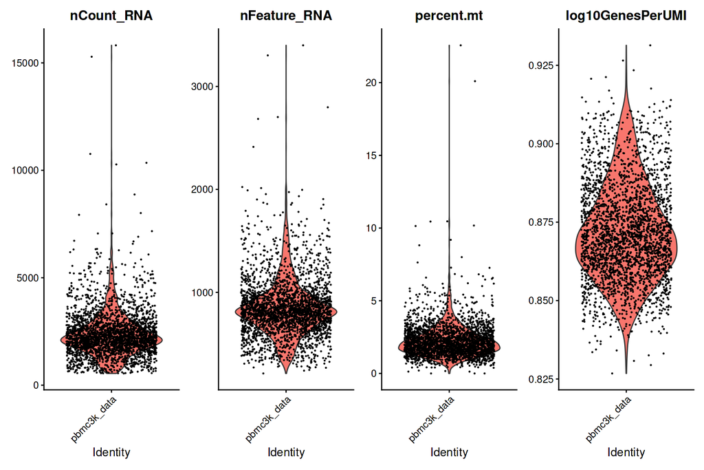

```r
# Visualize QC metrics as a violin plot
options(repr.plot.width=12, repr.plot.height=8)
VlnPlot(pbmc_seurat_object, features = c("nCount_RNA", "nFeature_RNA", "percent.mt", "log10GenesPerUMI"), ncol = 4)
```

```r
#  The filtering criteria applied to this dataset are as follows.(adjust to your dataset)
pbmc_seurat_object <- subset(pbmc_seurat_object,
               subset = (nFeature_RNA > 200 & nFeature_RNA < 2500) &
               (nCount_RNA > 500) &
               (log10GenesPerUMI > 0.80)&
               (percent.mt < 5)
              )
```

### 2-2. Normalizing the data

Count normalization is crucial for ensuring accurate comparisons of gene expression between cells (or samples).

- **Sequencing depth**: Accounting for sequencing depth is essential when comparing gene expression between cells.
- **Gene length**: Considering gene length is essential when comparing expression levels among different genes within the same cell. Without this consideration, it may seem like the number of reads mapped to a longer gene has the same count/expression as a shorter gene that is actually more highly expressed.

```r
# Normalized values will be stored in pbmc_seurat_object[["RNA"]]@data.
pbmc_seurat_object <- NormalizeData(pbmc_seurat_object)
```

### 2-3. Identifying highly variable features

Next, we determine a subset of features that display significant cell-to-cell variation in the dataset, meaning they are highly expressed in some cells while having low expression in others. This approach, employed by us and others, enhances the ability to identify biological signals in single-cell datasets.

```
When using repel, set xnudge and ynudge to 0 for optimal results

Warning message:
“Transformation introduced infinite values in continuous x-axis”
```

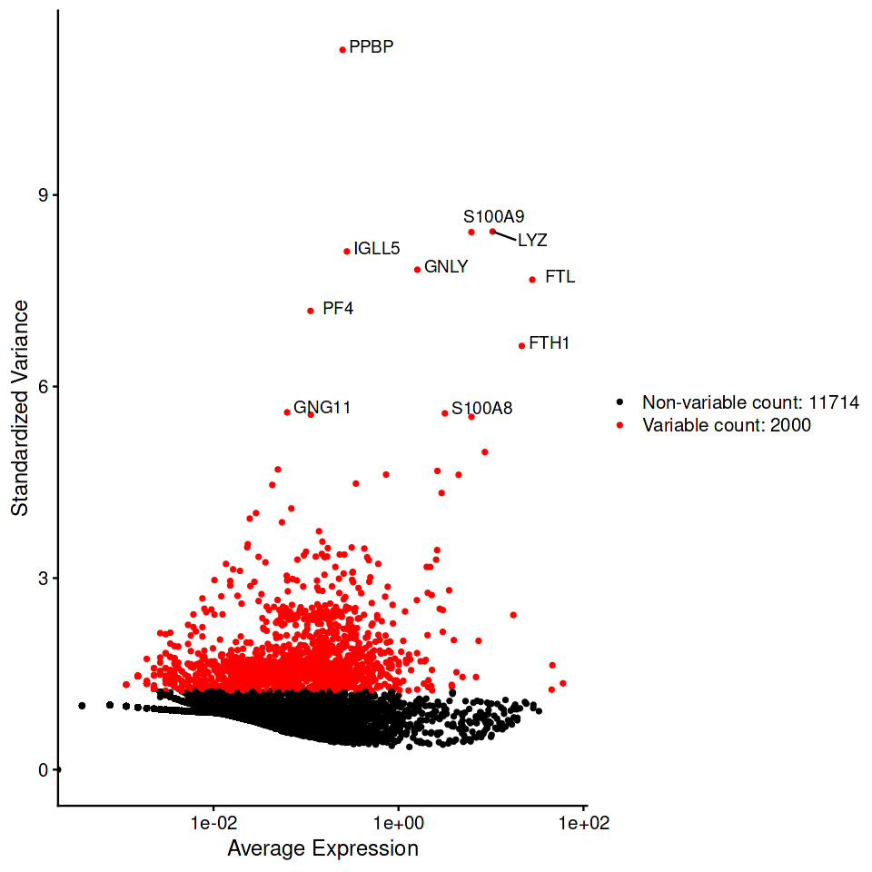

```r
pbmc_seurat_object <- FindVariableFeatures(pbmc_seurat_object, selection.method = "vst", nfeatures = 2000)

# Identify the 10 most highly variable genes
top10_variable_genes <- head(VariableFeatures(pbmc_seurat_object), 10)

options(repr.plot.width=8, repr.plot.height=8)
LabelPoints(plot = VariableFeaturePlot(pbmc_seurat_object), points = top10_variable_genes, repel = TRUE)
```

### 2-4. Scaling the data

we perform a linear transformation, commonly referred to as 'scaling,' which is a standard pre-processing step before applying dimension reduction techniques such as PCA.  
The ScaleData() function accomplishes the following:

- It shifts the expression of each gene so that the mean expression across cells becomes 0.
- It scales the expression of each gene so that the variance across cells becomes 1.

```r
# Scaled Value will be stored in pbmc_seurat_object[["RNA"]]@scale.data
all.genes <- rownames(pbmc_seurat_object)
pbmc_seurat_object <- ScaleData(pbmc_seurat_object, features = all.genes)
```

# 3. Dimension Reduction and Clustering

Return to Index

Next, we conduct Principal Component Analysis (PCA) on the scaled data. By default, the input comprises the features that were previously identified as variable, but you can specify a different subset using the "features" argument if desired.

### 3-1. Principal Component Analysis (PCA)

Principal Component Analysis (PCA) is a technique used to emphasize variation as well as similarity, and to bring out strong patterns in a dataset (dimensionality reduction).

```r
pbmc_seurat_object <- RunPCA(pbmc_seurat_object, features = VariableFeatures(object = pbmc_seurat_object))
```

```
PC_ 1
Positive:  CST3, TYROBP, LST1, AIF1, FTL, FTH1, LYZ, FCN1, S100A9, TYMP
	   FCER1G, CFD, LGALS1, S100A8, CTSS, LGALS2, SERPINA1, IFITM3, SPI1, CFP
	   PSAP, IFI30, SAT1, COTL1, S100A11, NPC2, GRN, LGALS3, GSTP1, PYCARD
Negative:  MALAT1, LTB, IL32, IL7R, CD2, B2M, ACAP1, CD27, STK17A, CTSW
	   CD247, GIMAP5, AQP3, CCL5, SELL, TRAF3IP3, GZMA, MAL, CST7, ITM2A
	   MYC, GIMAP7, HOPX, BEX2, LDLRAP1, GZMK, ETS1, ZAP70, TNFAIP8, RIC3
PC_ 2
Positive:  CD79A, MS4A1, TCL1A, HLA-DQA1, HLA-DQB1, HLA-DRA, LINC00926, CD79B, HLA-DRB1, CD74
	   HLA-DMA, HLA-DPB1, HLA-DQA2, CD37, HLA-DRB5, HLA-DMB, HLA-DPA1, FCRLA, HVCN1, LTB
	   BLNK, P2RX5, IGLL5, IRF8, SWAP70, ARHGAP24, FCGR2B, SMIM14, PPP1R14A, C16orf74
Negative:  NKG7, PRF1, CST7, GZMB, GZMA, FGFBP2, CTSW, GNLY, B2M, SPON2
	   CCL4, GZMH, FCGR3A, CCL5, CD247, XCL2, CLIC3, AKR1C3, SRGN, HOPX
	   TTC38, APMAP, CTSC, S100A4, IGFBP7, ANXA1, ID2, IL32, XCL1, RHOC
PC_ 3
Positive:  HLA-DQA1, CD79A, CD79B, HLA-DQB1, HLA-DPB1, HLA-DPA1, CD74, MS4A1, HLA-DRB1, HLA-DRA
	   HLA-DRB5, HLA-DQA2, TCL1A, LINC00926, HLA-DMB, HLA-DMA, CD37, HVCN1, FCRLA, IRF8
	   PLAC8, BLNK, MALAT1, SMIM14, PLD4, LAT2, IGLL5, P2RX5, SWAP70, FCGR2B
Negative:  PPBP, PF4, SDPR, SPARC, GNG11, NRGN, GP9, RGS18, TUBB1, CLU
	   HIST1H2AC, AP001189.4, ITGA2B, CD9, TMEM40, PTCRA, CA2, ACRBP, MMD, TREML1
	   NGFRAP1, F13A1, SEPT5, RUFY1, TSC22D1, MPP1, CMTM5, RP11-367G6.3, MYL9, GP1BA
PC_ 4
Positive:  HLA-DQA1, CD79B, CD79A, MS4A1, HLA-DQB1, CD74, HLA-DPB1, HIST1H2AC, PF4, TCL1A
	   SDPR, HLA-DPA1, HLA-DRB1, HLA-DQA2, HLA-DRA, PPBP, LINC00926, GNG11, HLA-DRB5, SPARC
	   GP9, AP001189.4, CA2, PTCRA, CD9, NRGN, RGS18, GZMB, CLU, TUBB1
Negative:  VIM, IL7R, S100A6, IL32, S100A8, S100A4, GIMAP7, S100A10, S100A9, MAL
	   AQP3, CD2, CD14, FYB, LGALS2, GIMAP4, ANXA1, CD27, FCN1, RBP7
	   LYZ, S100A11, GIMAP5, MS4A6A, S100A12, FOLR3, TRABD2A, AIF1, IL8, IFI6
PC_ 5
Positive:  GZMB, NKG7, S100A8, FGFBP2, GNLY, CCL4, CST7, PRF1, GZMA, SPON2
	   GZMH, S100A9, LGALS2, CCL3, CTSW, XCL2, CD14, CLIC3, S100A12, CCL5
	   RBP7, MS4A6A, GSTP1, FOLR3, IGFBP7, TYROBP, TTC38, AKR1C3, XCL1, HOPX
Negative:  LTB, IL7R, CKB, VIM, MS4A7, AQP3, CYTIP, RP11-290F20.3, SIGLEC10, HMOX1
	   PTGES3, LILRB2, MAL, CD27, HN1, CD2, GDI2, ANXA5, CORO1B, TUBA1B
	   FAM110A, ATP1A1, TRADD, PPA1, CCDC109B, ABRACL, CTD-2006K23.1, WARS, VMO1, FYB
```

The elbow plot is helpful when determining how many PCs we need to capture the majority of the variation in the data. The elbow plot visualizes the standard deviation of each PC. Where the elbow appears is usually the threshold for identifying the majority of the variation.

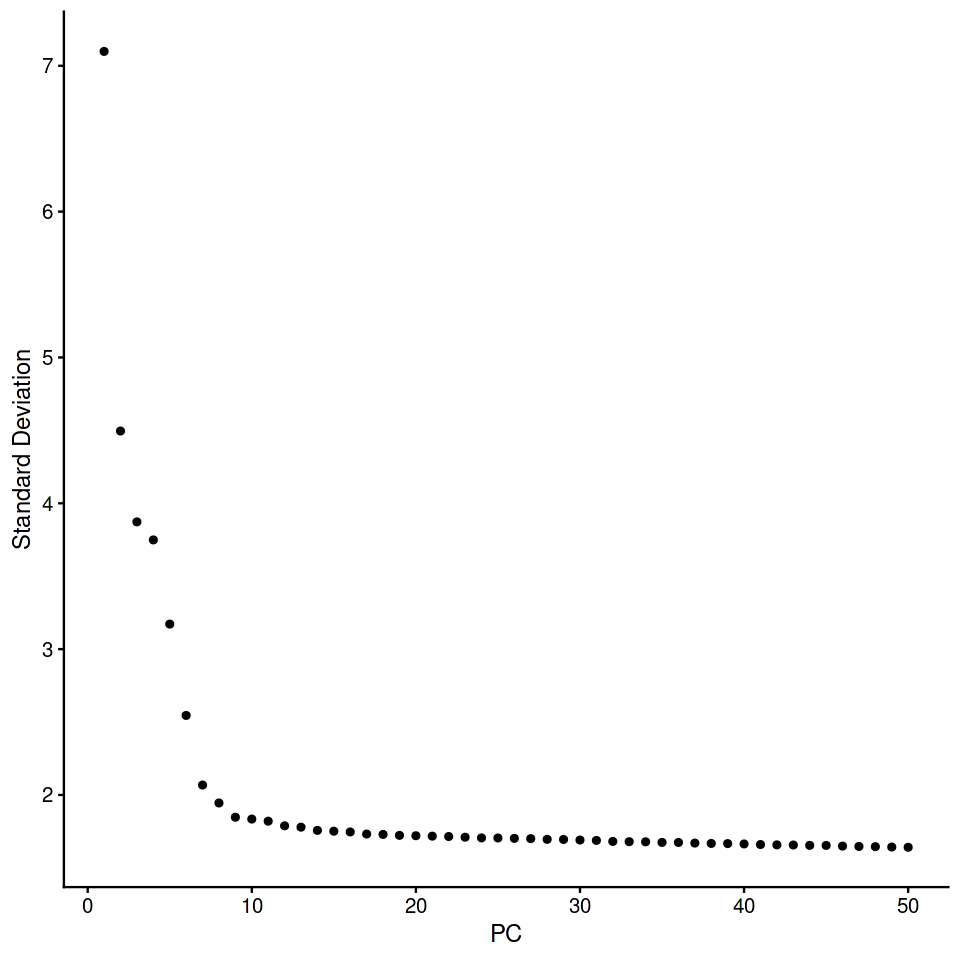

```r
ElbowPlot(object = pbmc_seurat_object,
          ndims = 50)
```

In this instance, we notice a distinct 'elbow' pattern emerging around PC9-10, indicating that the majority of the genuine signal is encompassed within the initial 10 principal components (PCs).

> **Cell cycle scoring**  
> Restricting the variation from uninteresting sources of variation (sequencing depth, cell cycle differences, mitochondrial expression, batch effects, etc.) are important to keep the major sources of variation.  
> Once the data is normalized for sequencing depth, we can assign each cell a score, based on its expression of G2/M and S phase markers. After scoring the cells for cell cycle, we would like to determine whether cell cycle is a major source of variation in our dataset using PCA

> ```
> s.genes <- cc.genes$s.genes
> g2m.genes <- cc.genes$g2m.genes
> pbmc_seurat_object <- CellCycleScoring(pbmc_seurat_object,
>                                        s.features = s.genes,
>                                        g2m.features = g2m.genes)
> ```

> # the CellCycleScoring result will be stored at pbmc_seurat_object[["Phase"]]

> ```
> DimPlot(pbmc_seurat_object,
>         reduction = "pca",
>         group.by= "Phase",
>         split.by = "Phase")
> ```

> We can use PCA visualization to check the extent of the cell cycle's influence on the data and make a decision on whether to regress out remove its effects.

> ```
> pbmc_seurat_object <- ScaleData(pbmc_seurat_object, vars.to.regress = c("S.Score", "G2M.Score"), features = rownames(pbmc_seurat_object))
> ```

### 3-2. Clustering

Seurat uses a graph-based clustering approach, which embeds cells in a graph structure, using a K-nearest neighbor (KNN) graph (by default), with edges drawn between cells with similar gene expression patterns. Then, it attempts to partition this graph into highly interconnected ‘quasi-cliques’ or ‘communities’

We will utilize the FindClusters() function to conduct graph-based clustering. The "resolution" parameter plays a crucial role in determining the level of detail in the resulting clusters and should be fine-tuned for each specific experiment. For datasets containing 3,000 to 5,000 cells, setting the resolution in the range of 0.4 to 1.4 typically produces satisfactory clustering results. Higher resolution values result in more clusters, which can be beneficial for larger datasets.

The FindClusters() function allows us to input multiple resolutions and automatically assess the clustering granularity, saving us the effort of running the function separately for each resolution to find the most suitable one.

```r
pbmc_seurat_object <- FindNeighbors(pbmc_seurat_object, dims = 1:10)
# Determine the clusters for various resolutions
pbmc_seurat_object <- FindClusters(object = pbmc_seurat_object,
                               resolution = c(0.5, 1.0, 1.2))
```

```
Modularity Optimizer version 1.3.0 by Ludo Waltman and Nees Jan van Eck

Number of nodes: 2638
Number of edges: 95965

Running Louvain algorithm...
Maximum modularity in 10 random starts: 0.8723
Number of communities: 9
Elapsed time: 0 seconds
Modularity Optimizer version 1.3.0 by Ludo Waltman and Nees Jan van Eck

Number of nodes: 2638
Number of edges: 95965

Running Louvain algorithm...
Maximum modularity in 10 random starts: 0.8031
Number of communities: 11
Elapsed time: 0 seconds
Modularity Optimizer version 1.3.0 by Ludo Waltman and Nees Jan van Eck

Number of nodes: 2638
Number of edges: 95965

Running Louvain algorithm...
Maximum modularity in 10 random starts: 0.7787
Number of communities: 11
Elapsed time: 0 seconds
```

```r
# Assign identity of clusters
Idents(object = pbmc_seurat_object) <- "RNA_snn_res.0.5"
```

### 3-3. UMAP visualization

To visualize the cell clusters, there are a few different dimensionality reduction techniques that can be helpful. The most popular methods include t-distributed stochastic neighbor embedding[(**t-SNE**)](https://kb.10xgenomics.com/hc/en-us/articles/217265066-What-is-t-Distributed-Stochastic-Neighbor-Embedding-t-SNE-) and Uniform Manifold Approximation and Projection[(**UMAP**)](https://umap-learn.readthedocs.io/en/latest/index.html) techniques

Both methods aim to group cells with similar local neighborhoods in high-dimensional space together in low-dimensional space. To use these methods, you need to specify the number of PCA dimensions to use for visualization, and it's recommended to use the same number of PCs as input for the clustering analysis. In this case, we will proceed with the UMAP method for visualizing the clusters.

```r
# If you haven't installed UMAP, you can do so via reticulate::py_install(packages =
# 'umap-learn')
pbmc_seurat_object <- RunUMAP(pbmc_seurat_object, dims = 1:10)
```

[output not shown]

[output cut: 27 more lines]

[output not shown]

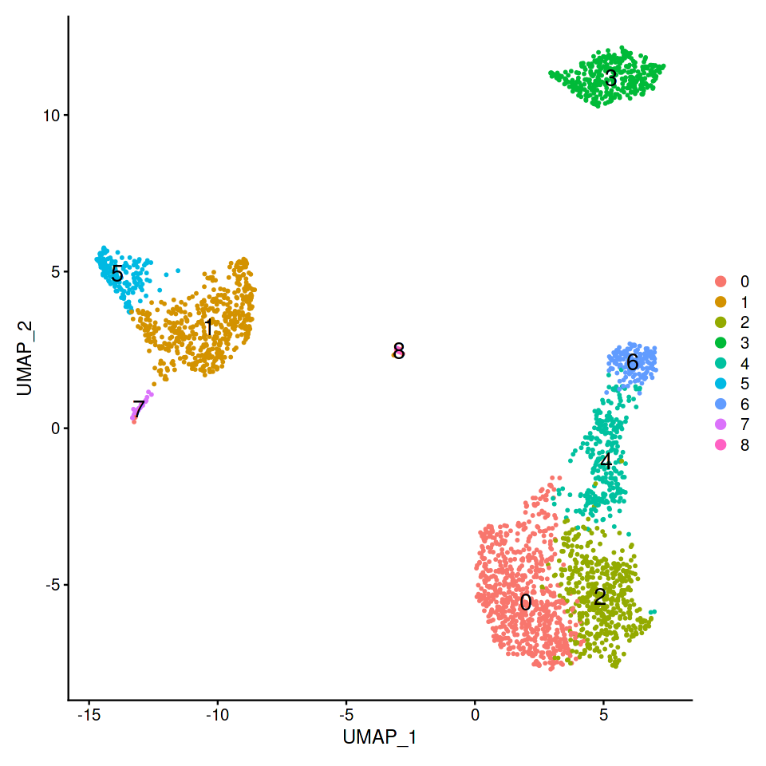

```r
# Plot the UMAP
DimPlot(pbmc_seurat_object,
        reduction = "umap",
        label = TRUE,
        label.size = 6)
```

Of course, visualization using t-SNE is also possible as shown below. Depending on the dataset's size, t-SNE may take more time compared to UMAP.

```
pbmc_seurat_object <- RunTSNE(pbmc_seurat_object, dims= 1:10)
DimPlot(pbmc_seurat_object,
        reduction = "tsne",
        label = TRUE,
        label.size = 6)
```

# 4. Annotation and Differentially Expressed Genes Analysis

Return to Index

Annotation involves assigning cell types to clusters based on their distinct characteristics, typically using markers and other relevant information. Seurat can help you find markers that define clusters via differential expression.

### 4-1. Exploring known cell type markers

Now that the cells are clustered, we can explore their cell type identities by examining known markers. For example if we were interested in exploring known immune cell markers

| Cell Type | Marker |
| --- | --- |
| CD14+ monocytes | CD14, LYZ |
| FCGR3A+ monocytes | FCGR3A, MS4A7 |
| Conventional dendritic cells | FCER1A, CST3 |
| Plasmacytoid dendritic cells | IL3RA, GZMB, SERPINF1, ITM2C |
| B cells | CD79A, MS4A1 |
| T cells | CD3D |
| CD4+ T cells | CD3D, IL7R, CCR7 |
| Memory CD4+ | IL7R, S100A4 |
| CD8+ T cells | CD3D, CD8A |
| Activated T cells | CREM, CD69 |
| NK cells | GNLY, NKG7 |
| Megakaryocytes | PPBP |
| Erythrocytes | HBB, HBA2 |

The FeaturePlot() and VlnPlot() function from seurat makes it easy to visualize a handful of genes using the gene IDs stored in the Seurat object.

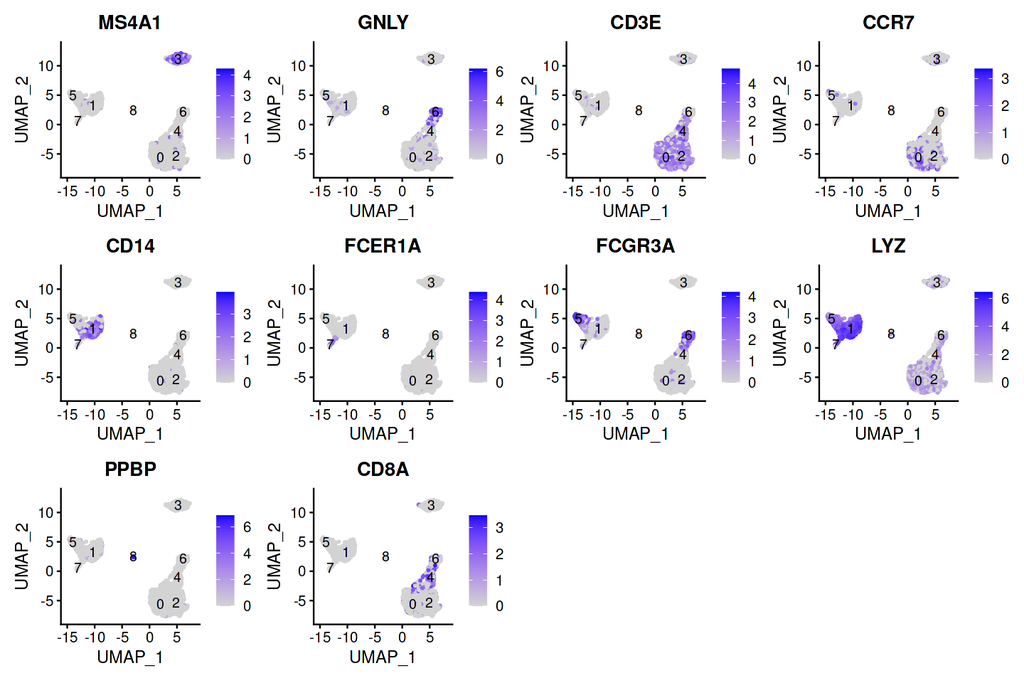

```r
options(repr.plot.width=12, repr.plot.height=8)
FeaturePlot(pbmc_seurat_object, features = c("MS4A1", "GNLY", "CD3E", "CCR7","CD14", "FCER1A", "FCGR3A", "LYZ", "PPBP",
    "CD8A"), label=T, ncol=4)
```

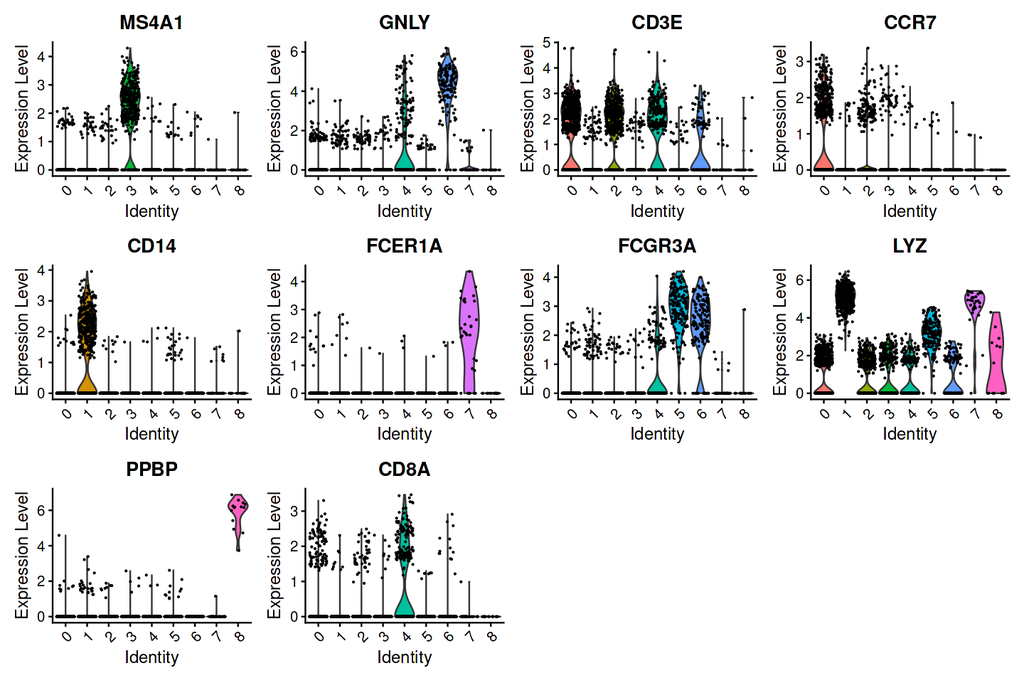

```r
VlnPlot(pbmc_seurat_object, features = c("MS4A1", "GNLY", "CD3E", "CCR7","CD14", "FCER1A", "FCGR3A", "LYZ", "PPBP",
    "CD8A"), ncol=4)
```

### 4-2. DEG analysis

FindAllMarkers() compares each cluster against all other clusters to identify potential marker genes.  
This function has three important arguments that serve as thresholds for determining whether a gene is considered a marker:

- logfc.threshold: This is the minimum log2 fold change for the average expression of a gene in the cluster relative to the average expression in all other clusters combined. The default threshold is 0.25.
- min.diff.pct: This sets the minimum percentage difference between the percentage of cells expressing the gene in the cluster and the percentage of cells expressing the gene in all other clusters combined.
- min.pct: This argument ensures that only genes detected in a minimum fraction of cells in either of the two populations are tested. It's meant to speed up the function by not testing genes that are very infrequently expressed. The default threshold is 0.1.

```r
# Depending on dataset, this command can quite take long to run
pbmc_seurat_object.markers <- FindAllMarkers(pbmc_seurat_object, only.pos = TRUE, min.pct = 0.25, logfc.threshold = 0.25)
pbmc_seurat_object.markers %>%
    group_by(cluster) %>%
    top_n(n = 5, wt = avg_log2FC) -> top5
```

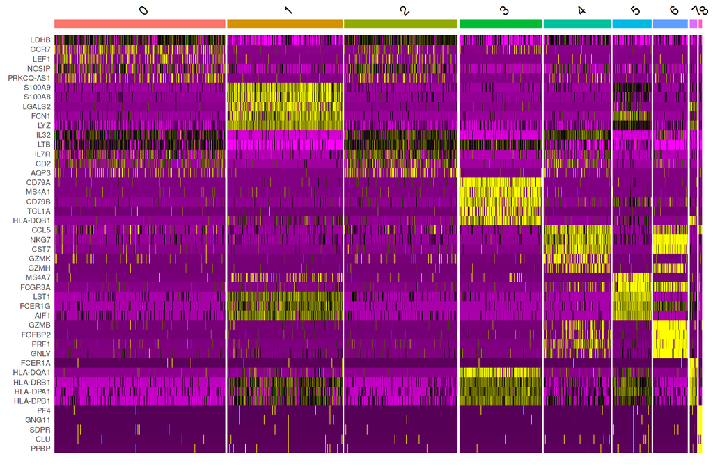

```r
DoHeatmap(pbmc_seurat_object, features = top5$gene) + NoLegend()
```

### 4-3. Assigning cell type identity to clusters(Annotation)

Lastly, we can assign cell types to each cluster based on cell type markers and differentially expressed genes (DEG).

```r
clusters <- pbmc_seurat_object$RNA_snn_res.0.5
cluster_names <- rep("Unknown", length(clusters))


cluster_names[clusters %in% c(3)] <- "B"
cluster_names[clusters %in% c(6)] <- "NK"
# cluster_names[clusters %in% c(0, 2, 4)] <- "T"
cluster_names[clusters %in% c( 4)] <- "CD8+ T"
# cluster_names[clusters %in% c(0,2)] <- "CD4+ T"
cluster_names[clusters %in% c(0)] <- "CD4+ T"
cluster_names[clusters %in% c(2)] <- "Memory CD4+ T"
cluster_names[clusters %in% c(1)] <- "CD14+ Mono"
cluster_names[clusters %in% c(7)] <- "cDC"
cluster_names[clusters %in% c(5)] <- "FCGR3A+ Mono"
cluster_names[clusters %in% c(8)] <- "Megakaryocytes"

pbmc_seurat_object <- AddMetaData(pbmc_seurat_object, metadata = cluster_names, col.name = "seurat_annotation")
Idents(pbmc_seurat_object) <- pbmc_seurat_object$seurat_annotation
```

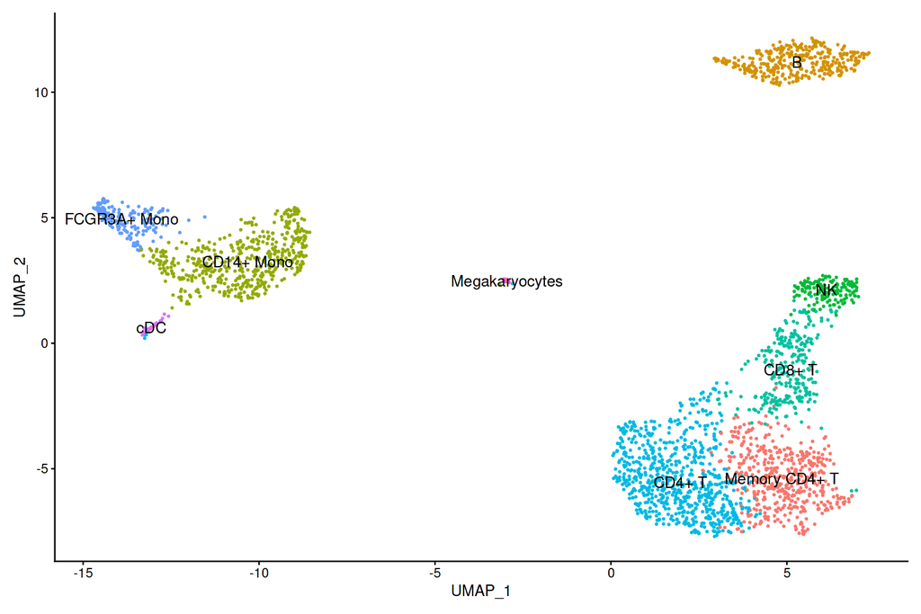

```r
DimPlot(pbmc_seurat_object, reduction = "umap", label = TRUE, label.size = 5 ,pt.size = 0.5 ) + NoLegend()
```

```r
saveRDS(pbmc_seurat_object, "../pbmc_3K.rds")
```